# IWC data

Tidying IWC data relevant for Southern Hemisphere catch from pelagic, land based and Soviet Union corrected numbers

SHL.CSV & SHL.TXT Individual data and Header records for catches from the Antarctic land-stations SHP1.CSV & SHP1.TXT Part 1 of Individual data and Header records for pelagic catches in the Antarctic SHP2.CSV & SHP2.TXT Part 2 of Individual data and Header records for pelagic catches in the Antarctic SU.CSV and SU.TXT Revised Individual data and Header records for catches in the Antarctic taken by the Soviet Union

Load required libraries

```r
library(tidyverse)
library(lubridate)
```

Whale species coding for variable `Sp`

```r
Species.code<-c(1:22)

# Species<-c("Pilot", "Bottlenose", "Killer", "Blue", "Fin",
#                "Sperm", "Humpback", "Sei", "Common Minke",
#                "Byrdes", "Right", "Gray", "Bairds Beaked",
#                "Baleen", "Pygmy Blue", "Pygmy Right",
#                "Cuviers Beaked", "Bowhead", "Beaked (unspec)",
#                "Antarctic Minke", "Sei/Brydes", "Dolphin")

Species<-c("Pilot", "Bottlenose", "Killer", "Baleen", "Baleen",
               "Sperm", "Baleen", "Baleen", "Common Minke",
               "Byrdes", "Right", "Gray", "Bairds Beaked",
               "Baleen", "Pygmy Blue", "Pygmy Right",
               "Cuviers Beaked", "Bowhead", "Beaked (unspec)",
               "Antarctic Minke", "Sei/Brydes", "Dolphin")

whale.codes<-data.frame(Species, Species.code)
```

Read in and inspect raw data frames

```r
# First time-series for SH ()
df_1_raw <- read.csv("IWC data/SHP1.csv")

# Second time-series for SH
df_2_raw <- read.csv("IWC data/SHP2.csv")

# Southern hemisphere land catch
df_3_raw <- read.csv("IWC data/SHL.csv")

# Soviet Union Antartic catch
df_4_raw <- read.csv("IWC data/SU.csv")

glimpse(df_1_raw)
```

```
Rows: 752,019
Columns: 40
$ CBt                                              <int> NA, NA, NA, NA, NA, NA, NA, NA, NA, NA, NA, NA, NA, NA, NA, NA, NA, NA, NA, NA, NA, NA, NA, NA, NA, …
$ Wh.No                                            <chr> "", "", "", "", "", "", "", "", "", "", "", "", "", "", "", "", "", "", "", "", "", "", "", "", "", …
$ Day                                              <int> 26, 26, 26, 26, 26, 26, 27, 27, 27, 27, 27, 27, 27, 27, 27, 28, 28, 28, 28, 28, 28, 28, 28, 28, 28, …
$ Mon                                              <int> 1, 1, 1, 1, 1, 1, 1, 1, 1, 1, 1, 1, 1, 1, 1, 1, 1, 1, 1, 1, 1, 1, 1, 1, 1, 1, 1, 1, 1, 1, 1, 1, 1, 1…
$ Year                                             <int> 1928, 1928, 1928, 1928, 1928, 1928, 1928, 1928, 1928, 1928, 1928, 1928, 1928, 1928, 1928, 1928, 1928…
$ Sp                                               <int> 8, 8, 8, 8, 8, 8, 8, 8, 8, 8, 8, 8, 8, 8, 8, 8, 8, 8, 8, 8, 8, 8, 8, 8, 8, 8, 8, 8, 8, 8, 8, 8, 8, 8…
$ Len                                              <int> 3400, 3600, 3500, 3800, 3600, 3700, 3900, 3800, 3600, 3500, 3800, 4000, 3600, 3800, 3900, 3500, 3600…
$ L.u                                              <int> 2, 2, 2, 2, 2, 2, 2, 2, 2, 2, 2, 2, 2, 2, 2, 2, 2, 2, 2, 2, 2, 2, 2, 2, 2, 2, 2, 2, 2, 2, 2, 2, 2, 2…
$ Sx                                               <int> 1, 1, 1, 2, 2, 1, 1, 1, 1, 1, 1, 2, 2, 2, 2, 2, 2, 2, 2, 2, 2, 1, 1, 2, 1, 1, 1, 1, 1, 1, 1, 1, 1, 1…
$ NoF                                              <int> 0, 0, 0, 0, 0, 0, 0, 0, 0, 0, 0, 0, 0, 0, 0, 0, 0, 0, 0, 0, 1, 0, 0, 1, 0, 0, 0, 0, 0, 0, 0, 0, 0, 0…
$ F1.L                                             <int> 0, 0, 0, 0, 0, 0, 0, 0, 0, 0, 0, 0, 0, 0, 0, 0, 0, 0, 0, 0, 300, 0, 0, 300, 0, 0, 0, 0, 0, 0, 0, 0, …
$ F1.S                                             <int> 0, 0, 0, 0, 0, 0, 0, 0, 0, 0, 0, 0, 0, 0, 0, 0, 0, 0, 0, 0, 0, 0, 0, 0, 0, 0, 0, 0, 0, 0, 0, 0, 0, 0…
$ F2.L                                             <int> 0, 0, 0, 0, 0, 0, 0, 0, 0, 0, 0, 0, 0, 0, 0, 0, 0, 0, 0, 0, 0, 0, 0, 0, 0, 0, 0, 0, 0, 0, 0, 0, 0, 0…
```

[output cut: 27 more lines]

```r
glimpse(df_2_raw)
```

```
Rows: 361,287
Columns: 40
$ CBt                                              <chr> "", "", "", "", "", "", "", "", "", "", "", "", "", "", "", "", "", "", "", "", "", "", "", "", "", …
$ Wh.No                                            <chr> "", "", "", "", "", "", "", "", "", "", "", "", "", "", "", "", "", "", "", "", "", "", "", "", "", …
$ Day                                              <int> 21, 21, 21, 21, 21, 21, 21, 21, 21, 21, 21, 21, 21, 21, 21, 21, 21, 21, 21, 21, 21, 21, 21, 21, 21, …
$ Mon                                              <int> 11, 11, 11, 11, 11, 11, 11, 11, 11, 11, 11, 11, 11, 11, 11, 11, 11, 11, 11, 11, 11, 11, 11, 11, 11, …
$ Year                                             <int> 1960, 1960, 1960, 1960, 1960, 1960, 1960, 1960, 1960, 1960, 1960, 1960, 1960, 1960, 1960, 1960, 1960…
$ Sp                                               <int> 6, 6, 6, 6, 6, 6, 6, 6, 6, 6, 6, 6, 6, 6, 6, 6, 6, 6, 6, 6, 6, 6, 6, 6, 6, 6, 6, 6, 6, 6, 6, 6, 6, 6…
$ Len                                              <int> 4300, 4200, 4500, 5100, 4500, 4200, 4100, 4600, 4200, 4300, 4200, 4100, 4600, 4400, 4000, 4000, 4200…
$ L.u                                              <int> 2, 2, 2, 2, 2, 2, 2, 2, 2, 2, 2, 2, 2, 2, 2, 2, 2, 2, 2, 2, 2, 2, 2, 2, 2, 2, 2, 2, 2, 2, 2, 2, 2, 2…
$ Sx                                               <int> 1, 1, 1, 1, 1, 1, 1, 1, 1, 1, 1, 1, 1, 1, 1, 1, 1, 1, 1, 1, 1, 1, 1, 1, 1, 1, 1, 1, 1, 1, 1, 1, 1, 1…
$ NoF                                              <int> 0, 0, 0, 0, 0, 0, 0, 0, 0, 0, 0, 0, 0, 0, 0, 0, 0, 0, 0, 0, 0, 0, 0, 0, 0, 0, 0, 0, 0, 0, 0, 0, 0, 0…
$ F1.L                                             <int> 0, 0, 0, 0, 0, 0, 0, 0, 0, 0, 0, 0, 0, 0, 0, 0, 0, 0, 0, 0, 0, 0, 0, 0, 0, 0, 0, 0, 0, 0, 0, 0, 0, 0…
$ F1.S                                             <int> 0, 0, 0, 0, 0, 0, 0, 0, 0, 0, 0, 0, 0, 0, 0, 0, 0, 0, 0, 0, 0, 0, 0, 0, 0, 0, 0, 0, 0, 0, 0, 0, 0, 0…
$ F2.L                                             <int> 0, 0, 0, 0, 0, 0, 0, 0, 0, 0, 0, 0, 0, 0, 0, 0, 0, 0, 0, 0, 0, 0, 0, 0, 0, 0, 0, 0, 0, 0, 0, 0, 0, 0…
```

[output cut: 27 more lines]

```r
glimpse(df_3_raw)
```

```
Rows: 178,871
Columns: 40
$ CBt                                              <chr> "HAU", "HAU", "HAU", "HAU", "HAU", "HAU", "HAU", "HAU", "HAU", "HAU", "HAU", "HAU", "HAU", "HAU", "H…
$ Wh.No                                            <chr> "", "", "", "", "", "", "", "", "", "", "", "", "", "", "", "", "", "", "", "", "", "", "", "", "", …
$ Day                                              <int> 24, 24, 27, 28, 30, 30, 4, 5, 6, 6, 8, 8, 10, 11, 12, 14, 15, 16, 16, 16, 17, 24, 27, 28, 28, 29, 30…
$ Mon                                              <int> 12, 12, 12, 12, 12, 12, 1, 1, 1, 1, 1, 1, 1, 1, 1, 1, 1, 1, 1, 1, 1, 12, 12, 12, 12, 12, 12, 12, 12,…
$ Year                                             <int> 1905, 1905, 1905, 1905, 1905, 1905, 1906, 1906, 1906, 1906, 1906, 1906, 1906, 1906, 1906, 1906, 1906…
$ Sp                                               <int> 5, 8, 8, 5, 5, 5, 8, 5, 5, 8, 8, 8, 8, 5, 5, 5, 5, 6, 6, 6, 5, 5, 8, 5, 8, 5, 5, 5, 5, 5, 5, 7, 8, 8…
$ Len                                              <int> 0, 0, 0, 0, 0, 0, 0, 0, 0, 0, 0, 0, 5200, 0, 0, 0, 0, 0, 0, 0, 0, 0, 0, 0, 0, 0, 0, 0, 0, 0, 0, 0, 0…
$ L.u                                              <int> 2, 2, 2, 2, 2, 2, 2, 2, 2, 2, 2, 2, 2, 2, 2, 2, 2, 2, 2, 2, 2, 2, 2, 2, 2, 2, 2, 2, 2, 2, 2, 2, 2, 2…
$ Sx                                               <int> 0, 0, 0, 0, 0, 0, 0, 0, 0, 0, 0, 0, 0, 0, 0, 0, 0, 1, 1, 1, 0, 0, 0, 0, 0, 0, 0, 0, 0, 0, 0, 0, 0, 0…
$ NoF                                              <int> 0, 0, 0, 0, 0, 0, 0, 0, 0, 0, 0, 0, 0, 0, 0, 0, 0, 0, 0, 0, 0, 0, 0, 0, 0, 0, 0, 0, 0, 0, 0, 0, 0, 0…
$ F1.L                                             <int> 0, 0, 0, 0, 0, 0, 0, 0, 0, 0, 0, 0, 0, 0, 0, 0, 0, 0, 0, 0, 0, 0, 0, 0, 0, 0, 0, 0, 0, 0, 0, 0, 0, 0…
$ F1.S                                             <int> 0, 0, 0, 0, 0, 0, 0, 0, 0, 0, 0, 0, 0, 0, 0, 0, 0, 0, 0, 0, 0, 0, 0, 0, 0, 0, 0, 0, 0, 0, 0, 0, 0, 0…
$ F2.L                                             <int> 0, 0, 0, 0, 0, 0, 0, 0, 0, 0, 0, 0, 0, 0, 0, 0, 0, 0, 0, 0, 0, 0, 0, 0, 0, 0, 0, 0, 0, 0, 0, 0, 0, 0…
```

[output cut: 27 more lines]

```r
glimpse(df_4_raw)
```

```
Rows: 173,265
Columns: 40
$ CBt                                              <int> NA, NA, NA, NA, NA, NA, NA, NA, NA, NA, NA, NA, NA, NA, NA, NA, NA, NA, NA, NA, NA, NA, NA, NA, NA, …
$ Wh.No                                            <chr> "", "", "", "", "", "", "", "", "", "", "", "", "", "", "", "", "", "", "", "", "", "", "", "", "", …
$ Day                                              <int> 30, 30, 30, 30, 30, 30, 30, 30, 30, 30, 30, 30, 30, 30, 30, 30, 30, 30, 30, 30, 30, 30, 30, 30, 30, …
$ Mon                                              <int> 1, 1, 1, 1, 1, 1, 1, 1, 1, 1, 1, 1, 1, 1, 1, 1, 1, 1, 1, 1, 1, 1, 1, 1, 1, 1, 1, 1, 1, 1, 1, 1, 1, 1…
$ Year                                             <int> 1958, 1958, 1958, 1958, 1958, 1958, 1958, 1958, 1958, 1958, 1958, 1958, 1958, 1958, 1958, 1958, 1958…
$ Sp                                               <int> 4, 7, 7, 7, 7, 7, 7, 7, 5, 5, 5, 5, 5, 5, 5, 5, 5, 5, 5, 5, 5, 5, 5, 5, 5, 5, 5, 5, 5, 5, 5, 5, 5, 5…
$ Len                                              <int> 0, 0, 0, 0, 0, 0, 0, 0, 0, 0, 0, 0, 0, 0, 0, 0, 0, 0, 0, 0, 0, 0, 0, 0, 0, 0, 0, 0, 0, 0, 0, 0, 0, 0…
$ L.u                                              <int> 2, 2, 2, 2, 2, 2, 2, 2, 2, 2, 2, 2, 2, 2, 2, 2, 2, 2, 2, 2, 2, 2, 2, 2, 2, 2, 2, 2, 2, 2, 2, 2, 2, 2…
$ Sx                                               <int> 0, 0, 0, 0, 0, 0, 0, 0, 0, 0, 0, 0, 0, 0, 0, 0, 0, 0, 0, 0, 0, 0, 0, 0, 0, 0, 0, 0, 0, 0, 0, 0, 0, 0…
$ NoF                                              <int> 0, 0, 0, 0, 0, 0, 0, 0, 0, 0, 0, 0, 0, 0, 0, 0, 0, 0, 0, 0, 0, 0, 0, 0, 0, 0, 0, 0, 0, 0, 0, 0, 0, 0…
$ F1.L                                             <int> 0, 0, 0, 0, 0, 0, 0, 0, 0, 0, 0, 0, 0, 0, 0, 0, 0, 0, 0, 0, 0, 0, 0, 0, 0, 0, 0, 0, 0, 0, 0, 0, 0, 0…
$ F1.S                                             <int> 0, 0, 0, 0, 0, 0, 0, 0, 0, 0, 0, 0, 0, 0, 0, 0, 0, 0, 0, 0, 0, 0, 0, 0, 0, 0, 0, 0, 0, 0, 0, 0, 0, 0…
$ F2.L                                             <int> 0, 0, 0, 0, 0, 0, 0, 0, 0, 0, 0, 0, 0, 0, 0, 0, 0, 0, 0, 0, 0, 0, 0, 0, 0, 0, 0, 0, 0, 0, 0, 0, 0, 0…
```

[output cut: 27 more lines]

```r
summary(df_1_raw)
```

```
      CBt            Wh.No                Day             Mon              Year            Sp              Len            L.u              Sx
 Min.   :10.0     Length:752019      Min.   : 0.00   Min.   : 0.000   Min.   :1928   Min.   : 0.000   Min.   :   0   Min.   :2.000   Min.   :0.000
 1st Qu.:16.0     Class :character   1st Qu.: 8.00   1st Qu.: 1.000   1st Qu.:1936   1st Qu.: 4.000   1st Qu.:6100   1st Qu.:2.000   1st Qu.:1.000
 Median :27.0     Mode  :character   Median :15.00   Median : 2.000   Median :1948   Median : 5.000   Median :6800   Median :2.000   Median :1.000
 Mean   :21.6                        Mean   :15.23   Mean   : 4.197   Mean   :1945   Mean   : 4.886   Mean   :6535   Mean   :2.027   Mean   :1.405
 3rd Qu.:29.0                        3rd Qu.:23.00   3rd Qu.: 4.000   3rd Qu.:1954   3rd Qu.: 5.000   3rd Qu.:7500   3rd Qu.:2.000   3rd Qu.:2.000
 Max.   :31.0                        Max.   :31.00   Max.   :12.000   Max.   :1960   Max.   :20.000   Max.   :9900   Max.   :4.000   Max.   :3.000
 NA's   :750424
      NoF              F1.L             F1.S             F2.L                F2.S               F.u             Lat              Mn             X
 Min.   :0.0000   Min.   :   0.0   Min.   :0.0000   Min.   :   0.0000   Min.   :0.000000   Min.   :3.000   Min.   : 0.00   Min.   : 0.00   Length:752019
 1st Qu.:0.0000   1st Qu.:   0.0   1st Qu.:0.0000   1st Qu.:   0.0000   1st Qu.:0.000000   1st Qu.:4.000   1st Qu.:59.00   1st Qu.: 0.00   Class :character
 Median :0.0000   Median :   0.0   Median :0.0000   Median :   0.0000   Median :0.000000   Median :4.000   Median :62.00   Median : 0.00   Mode  :character
 Mean   :0.1762   Mean   : 110.3   Mean   :0.1876   Mean   :   0.3751   Mean   :0.000589   Mean   :3.979   Mean   :60.66   Mean   : 3.71
 3rd Qu.:0.0000   3rd Qu.:   0.0   3rd Qu.:0.0000   3rd Qu.:   0.0000   3rd Qu.:0.000000   3rd Qu.:4.000   3rd Qu.:64.00   3rd Qu.: 0.00
 Max.   :9.0000   Max.   :2908.0   Max.   :9.0000   Max.   :2000.0000   Max.   :9.000000   Max.   :4.000   Max.   :83.00   Max.   :59.00

       Ac             Lon              Mn.1            X.1                 Ac.1            Exp           Sum.Ex          Nt                 SCo
 Min.   :0.000   Min.   :  0.00   Min.   : 0.000   Length:752019      Min.   :0.000   Min.   : 220   Min.   : 220   Length:752019      Min.   :101.0
 1st Qu.:2.000   1st Qu.: 20.00   1st Qu.: 0.000   Class :character   1st Qu.:2.000   1st Qu.:5720   1st Qu.:5720   Class :character   1st Qu.:999.0
 Median :2.000   Median : 42.00   Median : 0.000   Mode  :character   Median :2.000   Median :5981   Median :5981   Mode  :character   Median :999.0
 Mean   :1.862   Mean   : 58.32   Mean   : 3.605                      Mean   :1.862   Mean   :5979   Mean   :5979                      Mean   :946.9
 3rd Qu.:2.000   3rd Qu.: 88.00   3rd Qu.: 0.000                      3rd Qu.:2.000   3rd Qu.:6260   3rd Qu.:6260                      3rd Qu.:999.0
 Max.   :3.000   Max.   :180.00   Max.   :59.000                      Max.   :3.000   Max.   :6430   Max.   :6430                      Max.   :999.0

      S.q               S.d                S.s                L.D                Inf.               Fem              Mat             By
 Min.   : 0.0000   Min.   :0.000000   Min.   :0.000000   Min.   :0.000000   Min.   :0.000000   Min.   :0.0000   Min.   :0.000   Length:752019
 1st Qu.: 0.0000   1st Qu.:0.000000   1st Qu.:0.000000   1st Qu.:0.000000   1st Qu.:0.000000   1st Qu.:0.0000   1st Qu.:0.000   Class :character
 Median : 0.0000   Median :0.000000   Median :0.000000   Median :0.000000   Median :0.000000   Median :0.0000   Median :0.000   Mode  :character
 Mean   : 0.3195   Mean   :0.003153   Mean   :0.002352   Mean   :0.005411   Mean   :0.007662   Mean   :0.1805   Mean   :0.142
 3rd Qu.: 0.0000   3rd Qu.:0.000000   3rd Qu.:0.000000   3rd Qu.:0.000000   3rd Qu.:0.000000   3rd Qu.:0.0000   3rd Qu.:0.000
 Max.   :99.0000   Max.   :4.000000   Max.   :4.000000   Max.   :4.000000   Max.   :2.000000   Max.   :9.0000   Max.   :4.000

       IT                 Mk                 Sa               Txt          Notes.Extracted.on..22.Dec.20...........14.43.32
 Min.   :0.000000   Min.   :0.00e+00   Min.   :0.0e+00   Min.   :0.00000   Length:752019
 1st Qu.:0.000000   1st Qu.:0.00e+00   1st Qu.:0.0e+00   1st Qu.:0.00000   Class :character
 Median :0.000000   Median :0.00e+00   Median :0.0e+00   Median :0.00000   Mode  :character
 Mean   :0.009372   Mean   :2.39e-05   Mean   :1.3e-06   Mean   :0.04281
 3rd Qu.:0.000000   3rd Qu.:0.00e+00   3rd Qu.:0.0e+00   3rd Qu.:0.00000
 Max.   :9.000000   Max.   :3.00e+00   Max.   :1.0e+00   Max.   :8.00000
```

```r
summary(df_2_raw)
```

```
     CBt               Wh.No                Day             Mon              Year            Sp             Len            L.u             Sx
 Length:361287      Length:361287      Min.   : 0.00   Min.   : 0.000   Min.   :1960   Min.   : 2.00   Min.   :   0   Min.   :2.00   Min.   :0.000
 Class :character   Class :character   1st Qu.: 8.00   1st Qu.: 1.000   1st Qu.:1964   1st Qu.: 5.00   1st Qu.: 940   1st Qu.:2.00   1st Qu.:1.000
 Mode  :character   Mode  :character   Median :16.00   Median : 2.000   Median :1970   Median : 8.00   Median :4400   Median :2.00   Median :1.000
                                       Mean   :15.65   Mean   : 4.806   Mean   :1971   Mean   :10.46   Mean   :3678   Mean   :2.39   Mean   :1.487
                                       3rd Qu.:23.00   3rd Qu.:11.000   3rd Qu.:1976   3rd Qu.:20.00   3rd Qu.:5700   3rd Qu.:3.00   3rd Qu.:2.000
                                       Max.   :31.00   Max.   :12.000   Max.   :2019   Max.   :20.00   Max.   :9600   Max.   :3.00   Max.   :2.000
      NoF              F1.L              F1.S             F2.L                F2.S               F.u            Lat              Mn             X
 Min.   :0.0000   Min.   :   0.00   Min.   :0.0000   Min.   :   0.0000   Min.   :0.000000   Min.   :3.00   Min.   : 0.00   Min.   : 0.00   Length:361287
 1st Qu.:0.0000   1st Qu.:   0.00   1st Qu.:0.0000   1st Qu.:   0.0000   1st Qu.:0.000000   1st Qu.:3.00   1st Qu.:45.00   1st Qu.: 0.00   Class :character
 Median :0.0000   Median :   0.00   Median :0.0000   Median :   0.0000   Median :0.000000   Median :4.00   Median :54.00   Median : 0.00   Mode  :character
 Mean   :0.3754   Mean   :  83.57   Mean   :0.3491   Mean   :   0.2692   Mean   :0.001575   Mean   :3.61   Mean   :53.66   Mean   :13.45
 3rd Qu.:1.0000   3rd Qu.:   0.00   3rd Qu.:0.0000   3rd Qu.:   0.0000   3rd Qu.:0.000000   3rd Qu.:4.00   3rd Qu.:64.00   3rd Qu.:27.00
 Max.   :9.0000   Max.   :2400.00   Max.   :9.0000   Max.   :1400.0000   Max.   :2.000000   Max.   :4.00   Max.   :78.00   Max.   :59.00
       Ac             Lon              Mn.1          X.1                 Ac.1            Exp           Sum.Ex          Nt                 SCo
 Min.   :0.000   Min.   :  0.00   Min.   : 0.0   Length:361287      Min.   :0.000   Min.   :5600   Min.   :5600   Length:361287      Min.   :102.0
 1st Qu.:1.000   1st Qu.: 30.00   1st Qu.: 0.0   Class :character   1st Qu.:1.000   1st Qu.:6220   1st Qu.:6220   Class :character   1st Qu.:210.0
 Median :2.000   Median : 60.00   Median : 0.0   Mode  :character   Median :2.000   Median :6442   Median :6442   Mode  :character   Median :999.0
 Mean   :1.546   Mean   : 72.08   Mean   :13.3                      Mean   :1.546   Mean   :6347   Mean   :6347                      Mean   :740.9
 3rd Qu.:2.000   3rd Qu.:108.00   3rd Qu.:26.0                      3rd Qu.:2.000   3rd Qu.:6480   3rd Qu.:6480                      3rd Qu.:999.0
 Max.   :3.000   Max.   :180.00   Max.   :59.0                      Max.   :3.000   Max.   :6600   Max.   :6600                      Max.   :999.0
      S.q             S.d                S.s              L.D                Inf.              Fem              Mat              By
 Min.   : 0.00   Min.   :0.000000   Min.   :0.0000   Min.   :0.000000   Min.   :0.00000   Min.   :0.0000   Min.   :0.0000   Length:361287
 1st Qu.: 0.00   1st Qu.:0.000000   1st Qu.:0.0000   1st Qu.:0.000000   1st Qu.:0.00000   1st Qu.:0.0000   1st Qu.:0.0000   Class :character
 Median : 0.00   Median :0.000000   Median :0.0000   Median :0.000000   Median :0.00000   Median :0.0000   Median :0.0000   Mode  :character
 Mean   : 5.34   Mean   :0.000382   Mean   :0.2026   Mean   :0.001348   Mean   :0.07483   Mean   :0.4135   Mean   :0.2483
 3rd Qu.: 0.00   3rd Qu.:0.000000   3rd Qu.:0.0000   3rd Qu.:0.000000   3rd Qu.:0.00000   3rd Qu.:1.0000   3rd Qu.:0.0000
 Max.   :99.00   Max.   :1.000000   Max.   :4.0000   Max.   :2.000000   Max.   :2.00000   Max.   :9.0000   Max.   :3.0000
       IT                 Mk                 Sa                Txt          Notes.Extracted.on..22.Dec.20...........14.43.42
 Min.   :0.000000   Min.   :0.00e+00   Min.   :0.00e+00   Min.   :0.00000   Length:361287
 1st Qu.:0.000000   1st Qu.:0.00e+00   1st Qu.:0.00e+00   1st Qu.:0.00000   Class :character
 Median :0.000000   Median :0.00e+00   Median :0.00e+00   Median :0.00000   Mode  :character
 Mean   :0.007465   Mean   :1.38e-05   Mean   :6.92e-05   Mean   :0.02332
 3rd Qu.:0.000000   3rd Qu.:0.00e+00   3rd Qu.:0.00e+00   3rd Qu.:0.00000
 Max.   :5.000000   Max.   :1.00e+00   Max.   :1.00e+00   Max.   :8.00000
```

```r
summary(df_3_raw)
```

```
     CBt               Wh.No                Day             Mon              Year            Sp              Len            L.u              Sx
 Length:178871      Length:178871      Min.   : 0.00   Min.   : 0.000   Min.   :1905   Min.   : 0.000   Min.   :   0   Min.   :2.000   Min.   :0.00
 Class :character   Class :character   1st Qu.: 8.00   1st Qu.: 2.000   1st Qu.:1923   1st Qu.: 4.000   1st Qu.:5800   1st Qu.:2.000   1st Qu.:1.00
 Mode  :character   Mode  :character   Median :16.00   Median : 3.000   Median :1927   Median : 5.000   Median :6600   Median :2.000   Median :1.00
                                       Mean   :15.66   Mean   : 5.578   Mean   :1933   Mean   : 5.038   Mean   :6252   Mean   :2.118   Mean   :1.43
                                       3rd Qu.:23.00   3rd Qu.:11.000   3rd Qu.:1947   3rd Qu.: 5.000   3rd Qu.:7200   3rd Qu.:2.000   3rd Qu.:2.00
                                       Max.   :31.00   Max.   :12.000   Max.   :1965   Max.   :20.000   Max.   :9900   Max.   :4.000   Max.   :3.00
      NoF              F1.L              F1.S              F2.L               F2.S                F.u             Lat              Mn
 Min.   :0.0000   Min.   :   0.00   Min.   :0.00000   Min.   :   0.000   Min.   :0.0000000   Min.   :3.000   Min.   :49.00   Min.   : 0.000
 1st Qu.:0.0000   1st Qu.:   0.00   1st Qu.:0.00000   1st Qu.:   0.000   1st Qu.:0.0000000   1st Qu.:4.000   1st Qu.:54.00   1st Qu.: 0.000
 Median :0.0000   Median :   0.00   Median :0.00000   Median :   0.000   Median :0.0000000   Median :4.000   Median :54.00   Median : 0.000
 Mean   :0.0902   Mean   :  54.98   Mean   :0.06315   Mean   :   0.537   Mean   :0.0008162   Mean   :3.967   Mean   :55.85   Mean   : 3.552
 3rd Qu.:0.0000   3rd Qu.:   0.00   3rd Qu.:0.00000   3rd Qu.:   0.000   3rd Qu.:0.0000000   3rd Qu.:4.000   3rd Qu.:54.00   3rd Qu.: 0.000
 Max.   :9.0000   Max.   :2900.00   Max.   :2.00000   Max.   :1800.000   Max.   :2.0000000   Max.   :4.000   Max.   :65.00   Max.   :59.000
      X                   Ac             Lon             Mn.1            X.1                 Ac.1            Exp           Sum.Ex          Nt
 Length:178871      Min.   :1.000   Min.   :29.00   Min.   : 0.000   Length:178871      Min.   :1.000   Min.   :  20   Min.   :  20   Length:178871
 Class :character   1st Qu.:3.000   1st Qu.:36.00   1st Qu.: 0.000   Class :character   1st Qu.:3.000   1st Qu.:  80   1st Qu.:  80   Class :character
 Mode  :character   Median :3.000   Median :37.00   Median : 0.000   Mode  :character   Median :3.000   Median : 120   Median : 120   Mode  :character
                    Mean   :2.942   Mean   :41.31   Mean   : 4.585                      Mean   :2.942   Mean   :1367   Mean   :1367
                    3rd Qu.:3.000   3rd Qu.:38.00   3rd Qu.: 0.000                      3rd Qu.:3.000   3rd Qu.: 210   3rd Qu.: 210
                    Max.   :4.000   Max.   :64.00   Max.   :59.000                      Max.   :4.000   Max.   :5511   Max.   :5511
      SCo             S.q             S.d                S.s                L.D                Inf.               Fem               Mat
 Min.   :100.0   Min.   : 0.00   Min.   :0.000000   Min.   :0.000000   Min.   :0.000000   Min.   :0.000000   Min.   :0.00000   Min.   :0.00000
 1st Qu.:103.0   1st Qu.: 0.00   1st Qu.:0.000000   1st Qu.:0.000000   1st Qu.:0.000000   1st Qu.:0.000000   1st Qu.:0.00000   1st Qu.:0.00000
 Median :999.0   Median : 0.00   Median :0.000000   Median :0.000000   Median :0.000000   Median :0.000000   Median :0.00000   Median :0.00000
 Mean   :708.8   Mean   : 2.22   Mean   :0.000486   Mean   :0.009269   Mean   :0.004858   Mean   :0.002974   Mean   :0.09413   Mean   :0.08931
 3rd Qu.:999.0   3rd Qu.: 0.00   3rd Qu.:0.000000   3rd Qu.:0.000000   3rd Qu.:0.000000   3rd Qu.:0.000000   3rd Qu.:0.00000   3rd Qu.:0.00000
 Max.   :999.0   Max.   :99.00   Max.   :5.000000   Max.   :4.000000   Max.   :3.000000   Max.   :1.000000   Max.   :9.00000   Max.   :4.00000
    By                IT                 Mk                Sa                Txt         Notes.Extracted.on..22.Dec.20...........14.43.47
 Mode:logical   Min.   :0.000000   Min.   :0.0e+00   Min.   :0.000000   Min.   :0.0000   Length:178871
 NA's:178871    1st Qu.:0.000000   1st Qu.:0.0e+00   1st Qu.:0.000000   1st Qu.:0.0000   Class :character
                Median :0.000000   Median :0.0e+00   Median :0.000000   Median :0.0000   Mode  :character
                Mean   :0.003572   Mean   :9.5e-05   Mean   :0.001381   Mean   :0.1037
                3rd Qu.:0.000000   3rd Qu.:0.0e+00   3rd Qu.:0.000000   3rd Qu.:0.0000
                Max.   :3.000000   Max.   :1.0e+00   Max.   :2.000000   Max.   :8.0000
```

```r
summary(df_4_raw)
```

```
      CBt            Wh.No                Day             Mon              Year            Sp              Len            L.u              Sx
 Min.   : 0.00    Length:173265      Min.   : 1.00   Min.   : 1.000   Min.   :1958   Min.   : 0.000   Min.   :   0   Min.   :2.000   Min.   :0.000
 1st Qu.:58.00    Class :character   1st Qu.: 8.00   1st Qu.: 2.000   1st Qu.:1964   1st Qu.: 6.000   1st Qu.: 620   1st Qu.:3.000   1st Qu.:1.000
 Median :63.00    Mode  :character   Median :16.00   Median : 4.000   Median :1967   Median : 6.000   Median :1220   Median :3.000   Median :1.000
 Mean   :62.31                       Mean   :15.86   Mean   : 5.927   Mean   :1967   Mean   : 7.259   Mean   :1056   Mean   :2.751   Mean   :1.096
 3rd Qu.:66.00                       3rd Qu.:23.00   3rd Qu.:11.000   3rd Qu.:1970   3rd Qu.: 8.000   3rd Qu.:1510   3rd Qu.:3.000   3rd Qu.:2.000
 Max.   :69.00                       Max.   :31.00   Max.   :12.000   Max.   :1975   Max.   :20.000   Max.   :2890   Max.   :3.000   Max.   :2.000
 NA's   :169534
      NoF               F1.L             F1.S             F2.L               F2.S               F.u             Lat              Mn             X
 Min.   :0.00000   Min.   :  0.00   Min.   :0.0000   Min.   :  0.0000   Min.   :0.000000   Min.   :3.000   Min.   : 0.00   Min.   : 0.00   Length:173265
 1st Qu.:0.00000   1st Qu.:  0.00   1st Qu.:0.0000   1st Qu.:  0.0000   1st Qu.:0.000000   1st Qu.:3.000   1st Qu.:34.00   1st Qu.:11.00   Class :character
 Median :0.00000   Median :  0.00   Median :0.0000   Median :  0.0000   Median :0.000000   Median :3.000   Median :43.00   Median :27.00   Mode  :character
 Mean   :0.08178   Mean   : 14.47   Mean   :0.1159   Mean   :  0.1518   Mean   :0.001102   Mean   :3.249   Mean   :45.13   Mean   :27.09
 3rd Qu.:0.00000   3rd Qu.:  0.00   3rd Qu.:0.0000   3rd Qu.:  0.0000   3rd Qu.:0.000000   3rd Qu.:3.000   3rd Qu.:61.00   3rd Qu.:43.00
 Max.   :5.00000   Max.   :710.00   Max.   :9.0000   Max.   :469.0000   Max.   :2.000000   Max.   :4.000   Max.   :74.00   Max.   :59.00

       Ac            Lon              Mn.1           X.1                 Ac.1           Exp           Sum.Ex          Nt                 SCo
 Min.   :1.00   Min.   :  0.00   Min.   : 0.00   Length:173265      Min.   :1.00   Min.   :6300   Min.   :6300   Length:173265      Min.   :100.0
 1st Qu.:1.00   1st Qu.: 45.00   1st Qu.:10.00   Class :character   1st Qu.:1.00   1st Qu.:6442   1st Qu.:6442   Class :character   1st Qu.:999.0
 Median :1.00   Median : 75.00   Median :26.00   Mode  :character   Median :1.00   Median :6461   Median :6461   Mode  :character   Median :999.0
 Mean   :1.04   Mean   : 83.41   Mean   :26.75                      Mean   :1.04   Mean   :6448   Mean   :6448                      Mean   :837.8
 3rd Qu.:1.00   3rd Qu.:144.00   3rd Qu.:42.00                      3rd Qu.:1.00   3rd Qu.:6463   3rd Qu.:6463                      3rd Qu.:999.0
 Max.   :3.00   Max.   :180.00   Max.   :59.00                      Max.   :3.00   Max.   :6497   Max.   :6497                      Max.   :999.0

      S.q              S.d                 S.s                 L.D                Inf.               Fem              Mat              By
 Min.   : 0.000   Min.   :0.0000000   Min.   :0.0000000   Min.   :0.000000   Min.   :0.00e+00   Min.   :0.0000   Min.   :0.0000   Length:173265
 1st Qu.: 0.000   1st Qu.:0.0000000   1st Qu.:0.0000000   1st Qu.:0.000000   1st Qu.:0.00e+00   1st Qu.:0.0000   1st Qu.:0.0000   Class :character
 Median : 0.000   Median :0.0000000   Median :0.0000000   Median :0.000000   Median :0.00e+00   Median :0.0000   Median :0.0000   Mode  :character
 Mean   : 4.744   Mean   :0.0001731   Mean   :0.0007214   Mean   :0.000242   Mean   :4.62e-05   Mean   :0.6382   Mean   :0.3983
 3rd Qu.: 0.000   3rd Qu.:0.0000000   3rd Qu.:0.0000000   3rd Qu.:0.000000   3rd Qu.:0.00e+00   3rd Qu.:0.0000   3rd Qu.:1.0000
 Max.   :99.000   Max.   :1.0000000   Max.   :3.0000000   Max.   :4.000000   Max.   :2.00e+00   Max.   :9.0000   Max.   :4.0000

       IT          Mk                 Sa         Txt          Notes.Extracted.on..22.Dec.20...........14.43.50
 Min.   :0   Min.   :0.000000   Min.   :0   Min.   :0.00000   Length:173265
 1st Qu.:0   1st Qu.:0.000000   1st Qu.:0   1st Qu.:0.00000   Class :character
 Median :0   Median :0.000000   Median :0   Median :0.00000   Mode  :character
 Mean   :0   Mean   :0.000277   Mean   :0   Mean   :0.08911
 3rd Qu.:0   3rd Qu.:0.000000   3rd Qu.:0   3rd Qu.:0.00000
 Max.   :0   Max.   :1.000000   Max.   :0   Max.   :8.00000
```

Streamline the dataframes and rename variables as necessary

Lat and Lon have minutes variables `Mn` associated with them, and as such the second one read in is `Mn.1`. The same goes for `AC` and there is an unnamed variable to specify if the Lat or Lon measurement is North-South or East-West respectively.

```r
df_1_reduced <- select(df_1_raw, "Sum.Ex", "Day", "Mon", "Year", "Sp", "Len", "L.u", "Sx", "Lat", "Mn", "Lon","Mn.1", "Mat", "Ac", "X", "X.1", "Ac.1")

df_2_reduced <- select(df_2_raw, "Sum.Ex", "Day", "Mon","Year", "Sp", "Len", "L.u", "Sx", "Lat", "Mn", "Lon","Mn.1", "Mat", "Ac", "X", "X.1","Ac.1")

df_3_reduced <- select(df_3_raw, "Sum.Ex", "Day", "Mon","Year", "Sp", "Len", "L.u", "Sx", "Lat", "Mn", "Lon","Mn.1", "Mat", "Ac", "X", "X.1", "Ac.1")

df_4_reduced <- select(df_4_raw, "Sum.Ex", "Day", "Mon","Year", "Sp", "Len", "L.u", "Sx", "Lat", "Mn", "Lon","Mn.1", "Mat", "Ac", "X", "X.1", "Ac.1")


names(df_1_reduced) <- c("Exp.no", "Day", "Month", "Year","Species.code","Length","Length.unit","Sex","Lat","Mn","Lon","Mn.1","Mat","Ac","N.S",    "E.W","Ac.1")

names(df_2_reduced) <- c("Exp.no","Day", "Month", "Year","Species.code","Length","Length.unit","Sex","Lat","Mn","Lon","Mn.1","Mat","Ac","N.S",    "E.W","Ac.1")

names(df_3_reduced) <- c("Exp.no","Day", "Month", "Year","Species.code","Length","Length.unit","Sex","Lat","Mn","Lon","Mn.1","Mat","Ac","N.S",    "E.W","Ac.1")

names(df_4_reduced) <- c("Exp.no","Day", "Month", "Year","Species.code","Length","Length.unit","Sex","Lat","Mn","Lon","Mn.1","Mat","Ac","N.S",    "E.W","Ac.1")

# write.csv(df_1_reduced, "SHP1_v1.csv")
# write.csv(df_2_reduced, "SHP2_v1.csv")
# write.csv(df_3_reduced, "SHP3_v1.csv")
# write.csv(df_4_reduced, "SHP4_v1.csv")
```

```r
df_comb <- rbind(df_1_reduced, df_2_reduced, df_3_reduced, df_4_reduced)

df_comb_names <- left_join(df_comb, whale.codes)
```

```r
glimpse(df_comb_names)
```

```
Rows: 1,465,442
Columns: 18
$ Exp.no       <int> 5560, 5560, 5560, 5560, 5560, 5560, 5560, 5560, 5560, 5560, 5560, 5560, 5560, 5560, 5560, 5560, 5560, 5560, 5560, 5560, 5560, 5560, 5560…
$ Day          <int> 26, 26, 26, 26, 26, 26, 27, 27, 27, 27, 27, 27, 27, 27, 27, 28, 28, 28, 28, 28, 28, 28, 28, 28, 28, 28, 28, 28, 28, 29, 29, 29, 29, 29, …
$ Month        <int> 1, 1, 1, 1, 1, 1, 1, 1, 1, 1, 1, 1, 1, 1, 1, 1, 1, 1, 1, 1, 1, 1, 1, 1, 1, 1, 1, 1, 1, 1, 1, 1, 1, 1, 1, 1, 1, 1, 1, 1, 1, 1, 1, 1, 1, 1…
$ Year         <int> 1928, 1928, 1928, 1928, 1928, 1928, 1928, 1928, 1928, 1928, 1928, 1928, 1928, 1928, 1928, 1928, 1928, 1928, 1928, 1928, 1928, 1928, 1928…
$ Species.code <int> 8, 8, 8, 8, 8, 8, 8, 8, 8, 8, 8, 8, 8, 8, 8, 8, 8, 8, 8, 8, 8, 8, 8, 8, 8, 8, 8, 8, 8, 8, 8, 8, 8, 8, 8, 8, 8, 8, 8, 8, 8, 8, 8, 8, 8, 8…
$ Length       <int> 3400, 3600, 3500, 3800, 3600, 3700, 3900, 3800, 3600, 3500, 3800, 4000, 3600, 3800, 3900, 3500, 3600, 3200, 3900, 3600, 3500, 0, 4000, 3…
$ Length.unit  <int> 2, 2, 2, 2, 2, 2, 2, 2, 2, 2, 2, 2, 2, 2, 2, 2, 2, 2, 2, 2, 2, 2, 2, 2, 2, 2, 2, 2, 2, 2, 2, 2, 2, 2, 2, 2, 2, 2, 2, 2, 2, 2, 2, 2, 2, 2…
$ Sex          <int> 1, 1, 1, 2, 2, 1, 1, 1, 1, 1, 1, 2, 2, 2, 2, 2, 2, 2, 2, 2, 2, 1, 1, 2, 1, 1, 1, 1, 1, 1, 1, 1, 1, 1, 1, 1, 1, 1, 1, 2, 2, 2, 2, 2, 2, 2…
$ Lat          <int> 46, 46, 46, 46, 46, 46, 46, 46, 46, 46, 46, 46, 46, 46, 46, 46, 46, 46, 46, 46, 46, 46, 46, 46, 46, 46, 46, 46, 46, 46, 46, 46, 46, 46, …
$ Mn           <int> 0, 0, 0, 0, 0, 0, 0, 0, 0, 0, 0, 0, 0, 0, 0, 0, 0, 0, 0, 0, 0, 0, 0, 0, 0, 0, 0, 0, 0, 0, 0, 0, 0, 0, 0, 0, 0, 0, 0, 0, 0, 0, 0, 0, 0, 0…
$ Lon          <int> 67, 67, 67, 67, 67, 67, 67, 67, 67, 67, 67, 67, 67, 67, 67, 67, 67, 67, 67, 67, 67, 67, 67, 67, 67, 67, 67, 67, 67, 67, 67, 67, 67, 67, …
$ Mn.1         <int> 0, 0, 0, 0, 0, 0, 0, 0, 0, 0, 0, 0, 0, 0, 0, 0, 0, 0, 0, 0, 0, 0, 0, 0, 0, 0, 0, 0, 0, 0, 0, 0, 0, 0, 0, 0, 0, 0, 0, 0, 0, 0, 0, 0, 0, 0…
$ Mat          <int> 0, 0, 0, 0, 0, 0, 0, 0, 0, 0, 0, 0, 0, 0, 0, 0, 0, 0, 0, 0, 1, 0, 0, 1, 0, 0, 0, 0, 0, 0, 0, 0, 0, 0, 0, 0, 0, 0, 0, 0, 0, 0, 0, 0, 0, 0…
$ Ac           <int> 3, 3, 3, 3, 3, 3, 3, 3, 3, 3, 3, 3, 3, 3, 3, 3, 3, 3, 3, 3, 3, 3, 3, 3, 3, 3, 3, 3, 3, 3, 3, 3, 3, 3, 3, 3, 3, 3, 3, 3, 3, 3, 3, 3, 3, 3…
$ N.S          <chr> "S", "S", "S", "S", "S", "S", "S", "S", "S", "S", "S", "S", "S", "S", "S", "S", "S", "S", "S", "S", "S", "S", "S", "S", "S", "S", "S", "…
$ E.W          <chr> "W", "W", "W", "W", "W", "W", "W", "W", "W", "W", "W", "W", "W", "W", "W", "W", "W", "W", "W", "W", "W", "W", "W", "W", "W", "W", "W", "…
$ Ac.1         <int> 3, 3, 3, 3, 3, 3, 3, 3, 3, 3, 3, 3, 3, 3, 3, 3, 3, 3, 3, 3, 3, 3, 3, 3, 3, 3, 3, 3, 3, 3, 3, 3, 3, 3, 3, 3, 3, 3, 3, 3, 3, 3, 3, 3, 3, 3…
$ Species      <chr> "Baleen", "Baleen", "Baleen", "Baleen", "Baleen", "Baleen", "Baleen", "Baleen", "Baleen", "Baleen", "Baleen", "Baleen", "Baleen", "Balee…
```

```r
df_comb_names <- df_comb_names %>%
  mutate(date = make_date(Year, Month, Day),
         ID = row_number())

glimpse(df_comb_names)
```

```
Rows: 1,465,442
Columns: 20
$ Exp.no       <int> 5560, 5560, 5560, 5560, 5560, 5560, 5560, 5560, 5560, 5560, 5560, 5560, 5560, 5560, 5560, 5560, 5560, 5560, 5560, 5560, 5560, 5560, 5560…
$ Day          <int> 26, 26, 26, 26, 26, 26, 27, 27, 27, 27, 27, 27, 27, 27, 27, 28, 28, 28, 28, 28, 28, 28, 28, 28, 28, 28, 28, 28, 28, 29, 29, 29, 29, 29, …
$ Month        <int> 1, 1, 1, 1, 1, 1, 1, 1, 1, 1, 1, 1, 1, 1, 1, 1, 1, 1, 1, 1, 1, 1, 1, 1, 1, 1, 1, 1, 1, 1, 1, 1, 1, 1, 1, 1, 1, 1, 1, 1, 1, 1, 1, 1, 1, 1…
$ Year         <int> 1928, 1928, 1928, 1928, 1928, 1928, 1928, 1928, 1928, 1928, 1928, 1928, 1928, 1928, 1928, 1928, 1928, 1928, 1928, 1928, 1928, 1928, 1928…
$ Species.code <int> 8, 8, 8, 8, 8, 8, 8, 8, 8, 8, 8, 8, 8, 8, 8, 8, 8, 8, 8, 8, 8, 8, 8, 8, 8, 8, 8, 8, 8, 8, 8, 8, 8, 8, 8, 8, 8, 8, 8, 8, 8, 8, 8, 8, 8, 8…
$ Length       <int> 3400, 3600, 3500, 3800, 3600, 3700, 3900, 3800, 3600, 3500, 3800, 4000, 3600, 3800, 3900, 3500, 3600, 3200, 3900, 3600, 3500, 0, 4000, 3…
$ Length.unit  <int> 2, 2, 2, 2, 2, 2, 2, 2, 2, 2, 2, 2, 2, 2, 2, 2, 2, 2, 2, 2, 2, 2, 2, 2, 2, 2, 2, 2, 2, 2, 2, 2, 2, 2, 2, 2, 2, 2, 2, 2, 2, 2, 2, 2, 2, 2…
$ Sex          <int> 1, 1, 1, 2, 2, 1, 1, 1, 1, 1, 1, 2, 2, 2, 2, 2, 2, 2, 2, 2, 2, 1, 1, 2, 1, 1, 1, 1, 1, 1, 1, 1, 1, 1, 1, 1, 1, 1, 1, 2, 2, 2, 2, 2, 2, 2…
$ Lat          <int> 46, 46, 46, 46, 46, 46, 46, 46, 46, 46, 46, 46, 46, 46, 46, 46, 46, 46, 46, 46, 46, 46, 46, 46, 46, 46, 46, 46, 46, 46, 46, 46, 46, 46, …
$ Mn           <int> 0, 0, 0, 0, 0, 0, 0, 0, 0, 0, 0, 0, 0, 0, 0, 0, 0, 0, 0, 0, 0, 0, 0, 0, 0, 0, 0, 0, 0, 0, 0, 0, 0, 0, 0, 0, 0, 0, 0, 0, 0, 0, 0, 0, 0, 0…
$ Lon          <int> 67, 67, 67, 67, 67, 67, 67, 67, 67, 67, 67, 67, 67, 67, 67, 67, 67, 67, 67, 67, 67, 67, 67, 67, 67, 67, 67, 67, 67, 67, 67, 67, 67, 67, …
$ Mn.1         <int> 0, 0, 0, 0, 0, 0, 0, 0, 0, 0, 0, 0, 0, 0, 0, 0, 0, 0, 0, 0, 0, 0, 0, 0, 0, 0, 0, 0, 0, 0, 0, 0, 0, 0, 0, 0, 0, 0, 0, 0, 0, 0, 0, 0, 0, 0…
$ Mat          <int> 0, 0, 0, 0, 0, 0, 0, 0, 0, 0, 0, 0, 0, 0, 0, 0, 0, 0, 0, 0, 1, 0, 0, 1, 0, 0, 0, 0, 0, 0, 0, 0, 0, 0, 0, 0, 0, 0, 0, 0, 0, 0, 0, 0, 0, 0…
$ Ac           <int> 3, 3, 3, 3, 3, 3, 3, 3, 3, 3, 3, 3, 3, 3, 3, 3, 3, 3, 3, 3, 3, 3, 3, 3, 3, 3, 3, 3, 3, 3, 3, 3, 3, 3, 3, 3, 3, 3, 3, 3, 3, 3, 3, 3, 3, 3…
$ N.S          <chr> "S", "S", "S", "S", "S", "S", "S", "S", "S", "S", "S", "S", "S", "S", "S", "S", "S", "S", "S", "S", "S", "S", "S", "S", "S", "S", "S", "…
$ E.W          <chr> "W", "W", "W", "W", "W", "W", "W", "W", "W", "W", "W", "W", "W", "W", "W", "W", "W", "W", "W", "W", "W", "W", "W", "W", "W", "W", "W", "…
$ Ac.1         <int> 3, 3, 3, 3, 3, 3, 3, 3, 3, 3, 3, 3, 3, 3, 3, 3, 3, 3, 3, 3, 3, 3, 3, 3, 3, 3, 3, 3, 3, 3, 3, 3, 3, 3, 3, 3, 3, 3, 3, 3, 3, 3, 3, 3, 3, 3…
$ Species      <chr> "Baleen", "Baleen", "Baleen", "Baleen", "Baleen", "Baleen", "Baleen", "Baleen", "Baleen", "Baleen", "Baleen", "Baleen", "Baleen", "Balee…
$ date         <date> 1928-01-26, 1928-01-26, 1928-01-26, 1928-01-26, 1928-01-26, 1928-01-26, 1928-01-27, 1928-01-27, 1928-01-27, 1928-01-27, 1928-01-27, 192…
$ ID           <int> 1, 2, 3, 4, 5, 6, 7, 8, 9, 10, 11, 12, 13, 14, 15, 16, 17, 18, 19, 20, 21, 22, 23, 24, 25, 26, 27, 28, 29, 30, 31, 32, 33, 34, 35, 36, 3…
```

```r
df_effort <- df_comb_names %>%
  group_by(Exp.no) %>%
  mutate(Duration = length(unique(date))) %>%
  group_by(Exp.no,Species) %>%
  mutate(total_n = n(),
         Ind_CPUE = Duration/total_n)
```

```r
df_timeseries <- df_effort %>%
  group_by(Year, Species) %>%
  summarise(Catch_individuals = n())
glimpse(df_timeseries)
```

```
Rows: 321
Columns: 3
Groups: Year [109]
$ Year              <int> 1905, 1906, 1906, 1913, 1913, 1913, 1914, 1914, 1914, 1915, 1915, 1915, 1916, 1916, 1916, 1917, 1917, 1917, 1918, 1918, 1918, 1918,…
$ Species           <chr> "Baleen", "Baleen", "Sperm", "Baleen", "Right", "Sperm", "Baleen", "Right", "Sperm", "Baleen", "Right", "Sperm", "Baleen", "Right",…
$ Catch_individuals <int> 14, 23, 3, 488, 1, 3, 1926, 8, 3, 3712, 4, 1, 5661, 12, 17, 3370, 9, 35, 5, 3485, 2, 32, 16, 3536, 9, 12, 5171, 12, 26, 7460, 2, 10…
```

```r
summary(df_timeseries)
```

```
      Year        Species          Catch_individuals
 Min.   :1905   Length:321         Min.   :    1
 1st Qu.:1937   Class :character   1st Qu.:    9
 Median :1963   Mode  :character   Median :  344
 Mean   :1959                      Mean   : 4565
 3rd Qu.:1974                      3rd Qu.: 5171
 Max.   :2019                      Max.   :43974
```

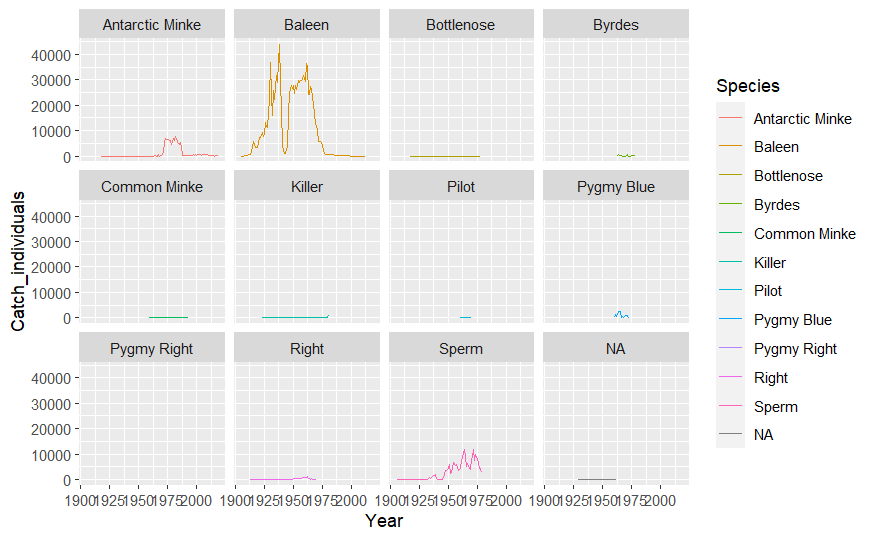

```r
ggplot(df_timeseries, aes(x=Year, y = Catch_individuals, colour = Species)) +
  geom_line() +
  facet_wrap(~Species)
```

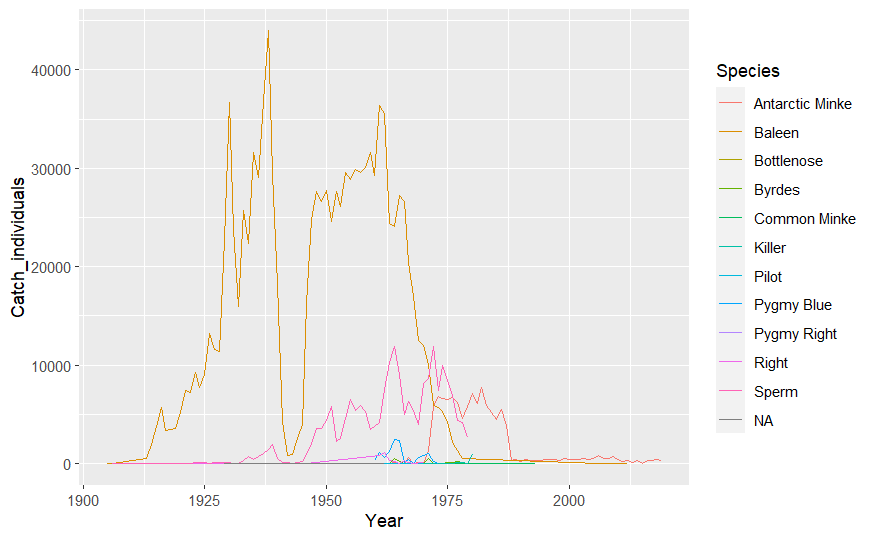

```r
ggplot(df_timeseries, aes(x=Year, y = Catch_individuals, colour = Species)) +
  geom_line()
```

Editing location data to account for all positive lat/lon values and converting to decimal degrees Quality control for measurements where location uncertainty present

```r
# df_dd <- df_comb_names
df_dd <- df_effort

##correct positive lat and long
df_dd$Lat[which(df_dd$N.S=="S")]<-df_dd$Lat[which(df_dd$N.S=="S")]*-1
df_dd$Lon[which(df_dd$E.W=="W")]<-df_dd$Lon[which(df_dd$E.W=="W")]*-1

##convert to decimal
df_dd$dec.Lat<-df_dd$Lat+(df_dd$Mn/60)
df_dd$dec.Lon<-df_dd$Lon+(df_dd$Mn.1/60)

##NA out the locational data that isnt certain:
df_dd$Lat[which(df_dd$Ac==0)]<-NA;df_dd$Lon[which(df_dd$Ac.1==0)]<-NA
```

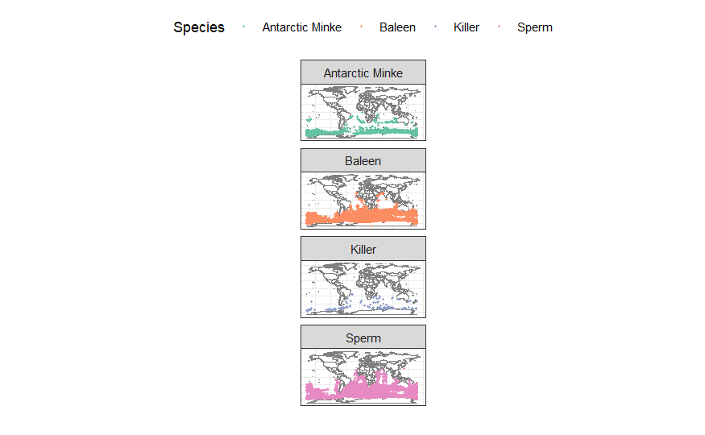

```r
# world<-map_data("world")

##map the data
# mp <- NULL
mapWorld <- borders("world", colour="gray50", fill="white") # create a layer of borders
whales<-c("Sperm", "Baleen", "Antarctic Minke", "Killer", "Dolphin")
sub.dd<-df_dd[df_dd$Species%in%whales, ]



 # png("Plots/world map.png", width=1600, height=5000)
  ggplot()+mapWorld +geom_point(data=sub.dd, aes(x=dec.Lon, y=dec.Lat, col=Species), size=0.5)+scale_colour_brewer(palette = "Set2", name = "Species")+coord_equal(ratio=1)+theme_bw()+theme(legend.position="top")+ xlab("")+ylab("")+theme(axis.ticks = element_blank(), axis.text.x = element_blank(),axis.text.y = element_blank())+facet_wrap(~Species, ncol=1)
```

```r
 # dev.off()
```

```r
library(sf)
df_sf <- st_as_sf(x = df_dd,
                  coords = c("dec.Lon","dec.Lat"),
                  crs = "+proj=longlat +datum=WGS84")

model_domain <- readRDS("model_domains/Stacey/BanzareBank.rds")

df_sf_update <- df_sf %>% st_set_crs(4326)

mod_domain_update <- model_domain %>% st_crs(4326)
```

```
old-style crs object detected; please recreate object with a recent sf::st_crs()
```

```r
df_overlap <- st_intersection(df_sf_update, model_domain)
```

```
old-style crs object detected; please recreate object with a recent sf::st_crs()
Warning: attribute variables are assumed to be spatially constant throughout all geometries
```

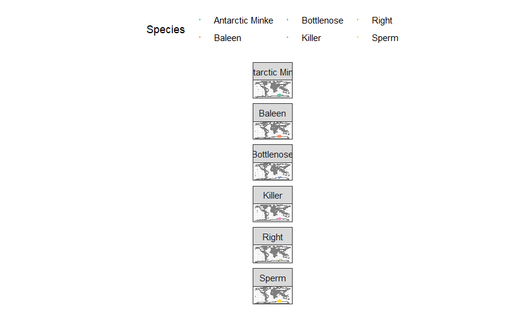

```r
df_BB_map <- sf_transform_xy(df_overlap, 4326,3347)

##convert to decimal
df_BB_map$dec.Lat<-df_BB_map$Lat+(df_BB_map$Mn/60)
df_BB_map$dec.Lon<-df_BB_map$Lon+(df_BB_map$Mn.1/60)

# png("Plots/BanzareBank map.png", width=1600, height=5000)
  ggplot()+mapWorld +geom_point(data=df_BB_map, aes(x=dec.Lon, y=dec.Lat, col=Species), size=0.5)+scale_colour_brewer(palette = "Set2", name = "Species")+coord_equal(ratio=1)+theme_bw()+theme(legend.position="top")+ xlab("")+ylab("")+theme(axis.ticks = element_blank(), axis.text.x = element_blank(),axis.text.y = element_blank())+facet_wrap(~Species, ncol=1)
```

```r
 # dev.off()
```

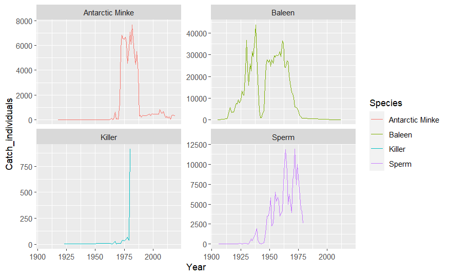

```r
sub.dd.ts <- sub.dd %>%
  group_by(Year, Species) %>%
  summarise(Catch_individuals = n()) %>%
  filter(!Catch_individuals == 0) %>%
  filter(!is.na(Catch_individuals))
ggplot(sub.dd.ts, aes(x=Year, y = Catch_individuals, colour = Species)) +
  geom_line() +
  facet_wrap(~Species, scales = "free_y")
```

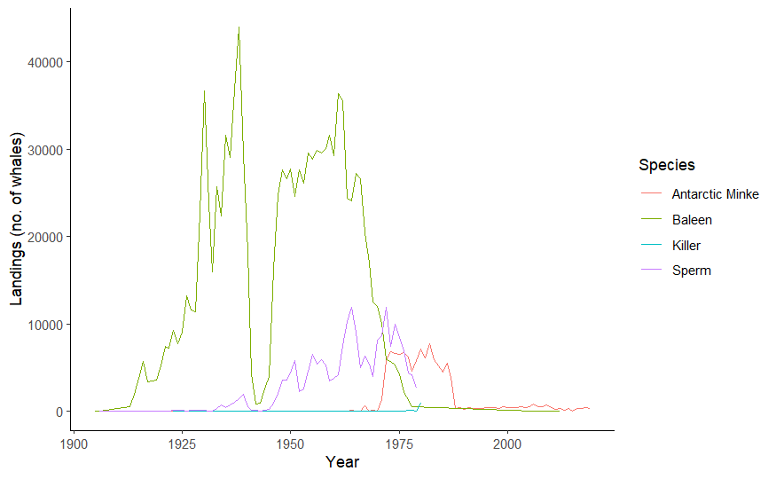

```r
# tiff(file="Plots/SH_Whale_Landings.tiff", width=6, height=4, units="in", res=500)
ggplot(sub.dd.ts, aes(x=Year, y = Catch_individuals, colour = Species)) +
  geom_line(size=0.5) +
  ylab("Landings (no. of whales)") +
  # scale_y_log10() +
  theme_classic()
```

```r
# dev.off()
```

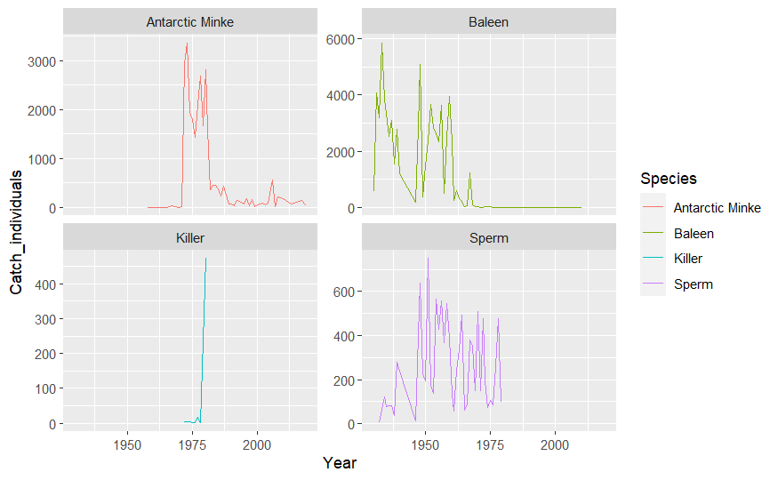

```r
sub_df_BB_map <- df_BB_map %>%
  group_by(Year, Species) %>%
  summarise(Catch_individuals = n()) %>%
  filter(!Catch_individuals == 0) %>%
  filter(!is.na(Catch_individuals))
whales<-c("Sperm", "Baleen", "Antarctic Minke", "Killer", "Dolphin")
sub.dd.BB <- sub_df_BB_map[sub_df_BB_map$Species%in%whales, ]

ggplot(sub.dd.BB, aes(x=Year, y = Catch_individuals, colour = Species)) +
  geom_line() +
  facet_wrap(~Species, scales = "free_y")
```

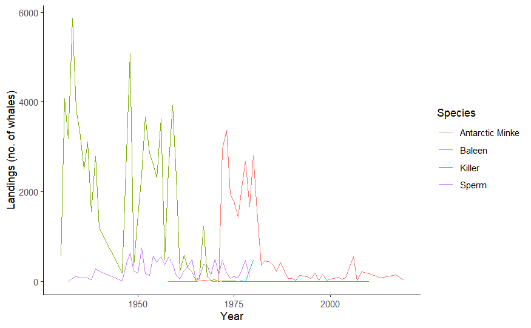

```r
# tiff(file="Plots/BanzareBank_Whale_Landings.tiff", width=6, height=4, units="in", res=500)
ggplot(sub.dd.BB, aes(x=Year, y = Catch_individuals, colour = Species)) +
  geom_line(size=0.5) +
  ylab("Landings (no. of whales)") +
  # scale_y_log10() +
  theme_classic()
```

```r
# dev.off()
```

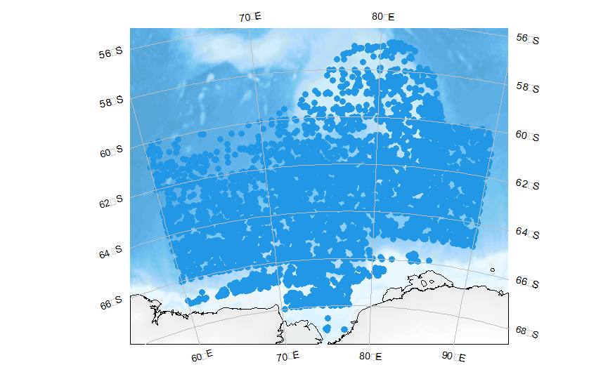

```r
library(SOmap)
# tiff(file="Plots/BanzareBank_Whale_Landings_Map.tiff", width=6, height=4, units="in", res=500)
SOmap_auto(df_BB_map$dec.Lon, df_BB_map$dec.Lat, input_lines = F, pcol = 4)
```

```r
# dev.off()


# df_map <- df_BB_map %>%
#   rename(lat = dec.Lat,
#          lon = dec.Lon)
#
# ## first transform our track to polar-stereographic coordinates
# library(sp)
# library(raster)
# ele_sp <- df_BB_map
# coordinates(ele_sp) <- c("lon", "lat")
# projection(ele_sp) <- "+proj=longlat +ellps=WGS84"
# ele_sp <- spTransform(ele_sp,
#             CRS("+proj=stere +lat_0=-90 +lat_ts=-71 +lon_0=0 +k=1 +x_0=0 +y_0=0
#             +datum=WGS84 +units=m +no_defs +ellps=WGS84 +towgs84=0,0,0"))
#
# ## plot the base map with ocean fronts shown
# SOmap(fronts = TRUE)
# ## add current marine protected areas
# SOmanagement(mpa = TRUE, mpa_col = "darkblue")
# ## add our track
# plot(ele_sp, col = "darkgreen", add = TRUE)
```

Body size stuff

```r
##function to convert ft and inches to cm
ft.in.2cm<-function(x){
    return(((as.numeric(substring(as.character(x), 1, 2))*12)+as.numeric(substring(as.character(x), 3, 4)))*2.54)
}

ft2cm<-function(x){
    return((as.numeric(substring(as.character(x), 1, 2))*12)*2.54)
}
```

```r
library(reshape2)
##remove spp with hardly any data:
# omit<-c("Cuviers Beaked", "Baleen", "Pygmy Blue")

##convert the ft and inches to cm

dd <- df_BB_map
# dd <- sub.dd

d1<-(melt(tapply(dd$Species, list(dd$Year, dd$Species), length)))
names(d1)<-c("Year", "Species", "Landings")

dd$Length[which(dd$Length==0000)]<-NA
dd$Length[which(dd$Length.unit==4)]<-ft.in.2cm(dd$Length[which(dd$Length.unit==4)])
dd$Length[which(dd$Length.unit==2)]<-ft2cm(dd$Length[which(dd$Length.unit==2)])

##remove shitty data (eg. massive individuals)
dd$Length[which(dd$Length>3400)]<-NA
```

W = a × L^b

Blue whale: https://www.sealifebase.ca/PopDyn/LWRelationshipList.php?ID=69007&GenusName=Balaenoptera&SpeciesName=musculus&fc=1174